# OBJECTIVE :

The classification goal is to predict the likelihood of a liability customer buying personal loans

# Domain:

Banking

Context : This case is about a bank (Thera Bank) whose management wants to explore ways of converting its liability customers to personal loan customers (while retaining them as depositors). A campaign that the bank ran last year for liability customers showed a healthy conversion rate of over 9% success. This has encouraged the retail marketing department to devise campaigns with better target marketing to increase the success ratio with minimal budget

# Import libraries

```python
import os #getting access to input files
import pandas as pd # Importing pandas for performing EDA
import numpy as np  # Importing numpy for Linear Algebric operations
import matplotlib.pyplot as plt # Importing for Data Visualization
import seaborn as sns # Importing for Data Visualization
from sklearn.model_selection import train_test_split
from sklearn.impute import SimpleImputer
from sklearn.linear_model import LogisticRegression
from sklearn.neighbors import KNeighborsClassifier
from sklearn.svm import SVC
from sklearn.naive_bayes import GaussianNB
from sklearn.preprocessing import MinMaxScaler
from sklearn import model_selection
from sklearn import metrics
from sklearn.metrics import accuracy_score
from sklearn.linear_model import LogisticRegression
from sklearn.metrics import accuracy_score,confusion_matrix,recall_score,precision_score,f1_score
%matplotlib inline
```

```python
os.chdir(r'C:\Users\harsh\Downloads')
print(os.getcwd())
```

```
C:\Users\harsh\Downloads
```

```python
df  = pd.read_csv('Bank_Personal_Loan_Modelling.csv') # Import the dataset
```

```python
print(df.head())# view the first 5 rows of the data
print("---------------------------------------------------------------")
print(df.tail())#view the last 5 rows of the data
```

```
   ID  Age  Experience  Income  ZIP Code  Family  CCAvg  Education  Mortgage  \
0   1   25           1      49     91107       4    1.6          1         0
1   2   45          19      34     90089       3    1.5          1         0
2   3   39          15      11     94720       1    1.0          1         0
3   4   35           9     100     94112       1    2.7          2         0
4   5   35           8      45     91330       4    1.0          2         0

   Personal Loan  Securities Account  CD Account  Online  CreditCard
0              0                   1           0       0           0
1              0                   1           0       0           0
2              0                   0           0       0           0
3              0                   0           0       0           0
4              0                   0           0       0           1
---------------------------------------------------------------
        ID  Age  Experience  Income  ZIP Code  Family  CCAvg  Education  \
```

[output cut: 19 more lines]

```python
df.shape
```

```
(5000, 14)
```

```python
df.info()
```

```
<class 'pandas.core.frame.DataFrame'>
RangeIndex: 5000 entries, 0 to 4999
Data columns (total 14 columns):
ID                    5000 non-null int64
Age                   5000 non-null int64
Experience            5000 non-null int64
Income                5000 non-null int64
ZIP Code              5000 non-null int64
Family                5000 non-null int64
CCAvg                 5000 non-null float64
Education             5000 non-null int64
Mortgage              5000 non-null int64
Personal Loan         5000 non-null int64
Securities Account    5000 non-null int64
CD Account            5000 non-null int64
Online                5000 non-null int64
CreditCard            5000 non-null int64
dtypes: float64(1), int64(13)
memory usage: 547.0 KB
```

we can see our data has 0 null values and all the variable are integer except ccavg that is float type

```python
df.isnull().sum() #faster way to check missing values but with info also we can find null values implementation is done above
```

```
ID                    0
Age                   0
Experience            0
Income                0
ZIP Code              0
Family                0
CCAvg                 0
Education             0
Mortgage              0
Personal Loan         0
Securities Account    0
CD Account            0
Online                0
CreditCard            0
dtype: int64
```

```python
#alternate way for checking missing values column wise and taking out percentage of missing value in a particular data set

def missing_check(data):
    total = data.isnull().sum().sort_values(ascending=False)   # total number of null values
    percent = (data.isnull().sum()/df.isnull().count()).sort_values(ascending=False)  # percentage of values that are null
    missing_data = pd.concat([total, percent], axis=1, keys=['Total', 'Percent'])  # putting the above two together
    return missing_data # return the dataframe
missing_check(df)
```

|  | Total | Percent |
| --- | --- | --- |
| CreditCard | 0 | 0.0 |
| Online | 0 | 0.0 |
| CD Account | 0 | 0.0 |
| Securities Account | 0 | 0.0 |
| Personal Loan | 0 | 0.0 |
| Mortgage | 0 | 0.0 |
| Education | 0 | 0.0 |
| CCAvg | 0 | 0.0 |
| Family | 0 | 0.0 |
| ZIP Code | 0 | 0.0 |
| Income | 0 | 0.0 |
| Experience | 0 | 0.0 |
| Age | 0 | 0.0 |
| ID | 0 | 0.0 |

```python
#this describe function gives five number summary for the given data and it also provide other stats for numerical data
#condition (data should be numerical int or float or boolean(1 binary digit which can store either 0 or 1))
df.describe().T
```

|  | count | mean | std | min | 25% | 50% | 75% | max |
| --- | --- | --- | --- | --- | --- | --- | --- | --- |
| ID | 5000.0 | 2500.500000 | 1443.520003 | 1.0 | 1250.75 | 2500.5 | 3750.25 | 5000.0 |
| Age | 5000.0 | 45.338400 | 11.463166 | 23.0 | 35.00 | 45.0 | 55.00 | 67.0 |
| Experience | 5000.0 | 20.104600 | 11.467954 | -3.0 | 10.00 | 20.0 | 30.00 | 43.0 |
| Income | 5000.0 | 73.774200 | 46.033729 | 8.0 | 39.00 | 64.0 | 98.00 | 224.0 |
| ZIP Code | 5000.0 | 93152.503000 | 2121.852197 | 9307.0 | 91911.00 | 93437.0 | 94608.00 | 96651.0 |
| Family | 5000.0 | 2.396400 | 1.147663 | 1.0 | 1.00 | 2.0 | 3.00 | 4.0 |
| CCAvg | 5000.0 | 1.937938 | 1.747659 | 0.0 | 0.70 | 1.5 | 2.50 | 10.0 |
| Education | 5000.0 | 1.881000 | 0.839869 | 1.0 | 1.00 | 2.0 | 3.00 | 3.0 |
| Mortgage | 5000.0 | 56.498800 | 101.713802 | 0.0 | 0.00 | 0.0 | 101.00 | 635.0 |
| Personal Loan | 5000.0 | 0.096000 | 0.294621 | 0.0 | 0.00 | 0.0 | 0.00 | 1.0 |
| Securities Account | 5000.0 | 0.104400 | 0.305809 | 0.0 | 0.00 | 0.0 | 0.00 | 1.0 |
| CD Account | 5000.0 | 0.060400 | 0.238250 | 0.0 | 0.00 | 0.0 | 0.00 | 1.0 |
| Online | 5000.0 | 0.596800 | 0.490589 | 0.0 | 0.00 | 1.0 | 1.00 | 1.0 |
| CreditCard | 5000.0 | 0.294000 | 0.455637 | 0.0 | 0.00 | 0.0 | 1.00 | 1.0 |

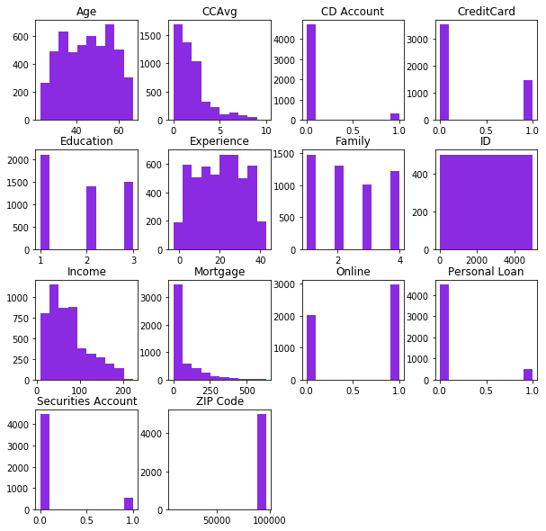

```python
df.hist(figsize=(10,10),color="blueviolet",grid=False)
plt.show()
```

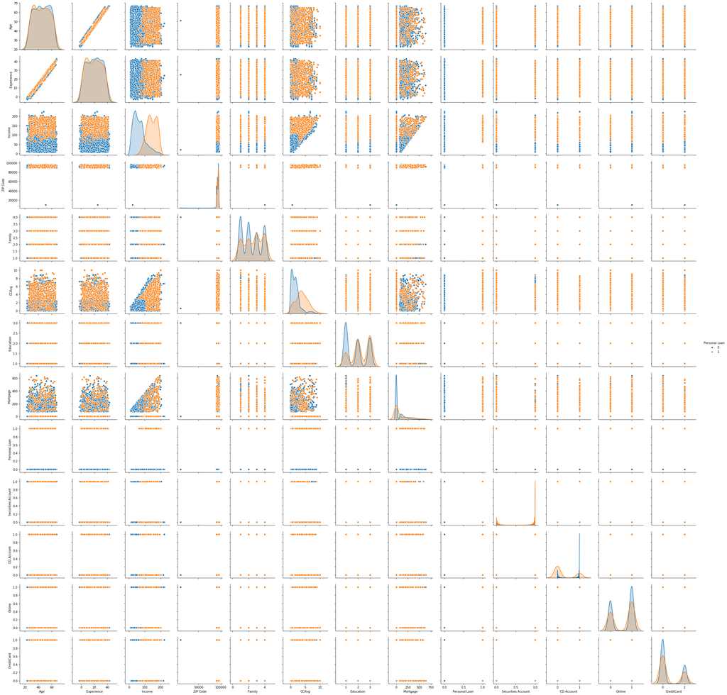

```python
sns.pairplot(df.iloc[:,1:], hue='Personal Loan')
```

From above pair plot it looks like whose customer income is high they more likely to accept Personal Loan

In dataset it is visible that "Age" feature is almost normally distributed where majority of customers are between age 30 to 60 years.And we can also see median is equal to mean.

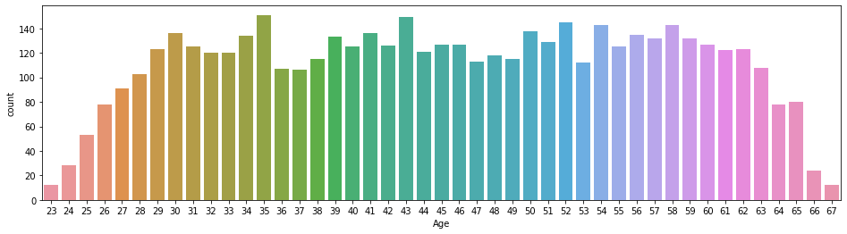

```python
plt.figure(figsize=(16,4))
sns.set_color_codes()
sns.countplot(df["Age"])
```

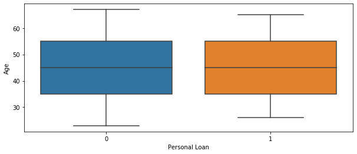

```python
plt.figure(figsize=(10,4))
sns.set_color_codes()
sns.boxplot(y=df["Age"],x=df["Personal Loan"])
```

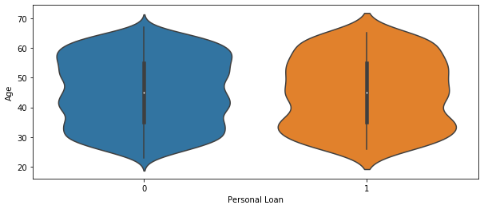

```python
plt.figure(figsize=(10,4))
sns.set_color_codes()
sns.violinplot(y=df["Age"],x=df["Personal Loan"])
```

Here we can see "Age" feature is almost normally distributed where majority of customers are between age 30 to 60 years.Also we can see median is equal to mean.

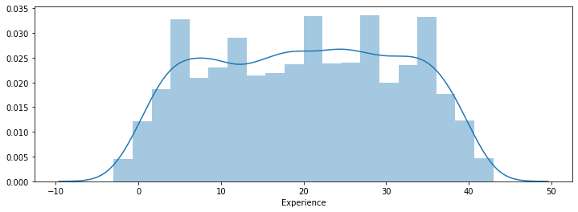

```python
plt.figure(figsize=(12,4))
sns.set_color_codes()
sns.distplot(df["Experience"])
```

"Experience" feature is also almost normally distibuted and mean is also equal to median.But there are some negative values present which should be deleted, as Experience can not be negative.

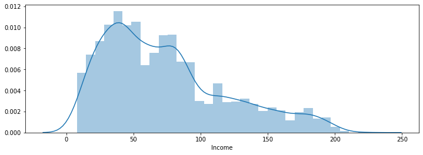

```python
plt.figure(figsize=(12,4))
sns.set_color_codes()
sns.distplot(df["Income"])
```

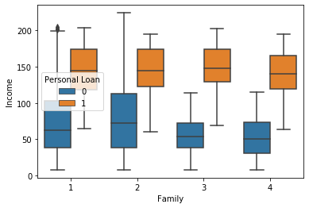

```python
sns.boxplot(x="Family",y="Income",hue="Personal Loan",data=df)
```

Families with income less than 100K are less likely to take loan,than families with high income

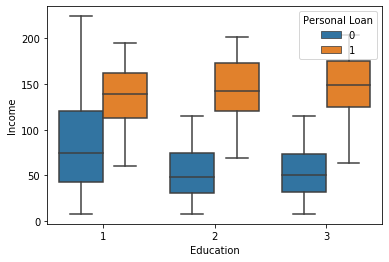

```python
sns.boxplot(x='Education',y='Income',hue='Personal Loan',data=df)
```

Here the customers whose education level is 1 is having more income than the others.

We can see the customers who has taken the Personal Loan have the same Income levels.

Also the Customers with education levels 2 and 3 have same income level with no Personal Loan.

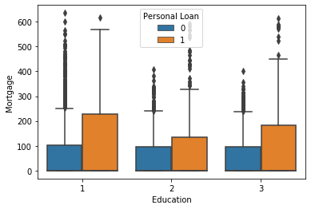

```python
sns.boxplot(x="Education", y='Mortgage', hue="Personal Loan", data=df)
```

There are so many outliers in each case. But the customers with and without Personal Loan have high Mortage.

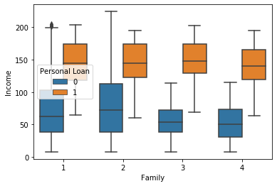

```python
sns.boxplot(x="Family",y="Income",hue="Personal Loan",data=df)
```

Families with income less than 100K are less likely to take loan,than families with high income

```python
df[df['Experience'] < 0]['Experience'].count()
```

```
52
```

we can see there are 52 negative values which are error values or false values

Removing the negative value

```python
new_df = df.copy()
```

```python
print("the total customers whose experience is in negative is {}".format((new_df[new_df['Experience']<0]).shape[0]))
```

```
the total customers whose experience is in negative is 52
```

```python
#converting negative experience values into positive
new_df['Experience'] = new_df['Experience'].apply(lambda x : abs(x) if(x<0) else x)
```

```python
print("now after manipulation total customers whose experience is in negative is {}".format((new_df[new_df['Experience']<0]).shape[0]))
```

```
now after manipulation total customers whose experience is in negative is 0
```

```python
#display first 5 rows of dataframe.
new_df.skew()
```

[output not shown]

```python
#dropping ID and ZIP Code columns from new_bank_df dataframe
new_df.drop(['ID','ZIP Code'],axis=1,inplace=True)
```

We can see for "Income" , "CCAvg" , "Mortgage" distribution is positively skewed For "CCAvg" majority of the customers spend less than 2.5K and the average spending is between 0-10K Income and CCAvg is moderately correlated Experience and Age gives a positive correlation. Families with income less than 100K are less likely to take loan,than families with high income. There is no that much impact on Personal Loan if we consider Family attribute. But the Family with size 3 is taking more Personal loan as compare to other family size

```python
corrlate = new_df.corr()
corrlate
```

|  | Age | Experience | Income | Family | CCAvg | Education | Mortgage | Personal Loan | Securities Account | CD Account | Online | CreditCard |
| --- | --- | --- | --- | --- | --- | --- | --- | --- | --- | --- | --- | --- |
| Age | 1.000000 | 0.993991 | -0.055269 | -0.046418 | -0.052012 | 0.041334 | -0.012539 | -0.007726 | -0.000436 | 0.008043 | 0.013702 | 0.007681 |
| Experience | 0.993991 | 1.000000 | -0.046876 | -0.051851 | -0.049738 | 0.013919 | -0.011097 | -0.008304 | -0.000989 | 0.009735 | 0.014051 | 0.008851 |
| Income | -0.055269 | -0.046876 | 1.000000 | -0.157501 | 0.645984 | -0.187524 | 0.206806 | 0.502462 | -0.002616 | 0.169738 | 0.014206 | -0.002385 |
| Family | -0.046418 | -0.051851 | -0.157501 | 1.000000 | -0.109275 | 0.064929 | -0.020445 | 0.061367 | 0.019994 | 0.014110 | 0.010354 | 0.011588 |
| CCAvg | -0.052012 | -0.049738 | 0.645984 | -0.109275 | 1.000000 | -0.136124 | 0.109905 | 0.366889 | 0.015086 | 0.136534 | -0.003611 | -0.006689 |
| Education | 0.041334 | 0.013919 | -0.187524 | 0.064929 | -0.136124 | 1.000000 | -0.033327 | 0.136722 | -0.010812 | 0.013934 | -0.015004 | -0.011014 |
| Mortgage | -0.012539 | -0.011097 | 0.206806 | -0.020445 | 0.109905 | -0.033327 | 1.000000 | 0.142095 | -0.005411 | 0.089311 | -0.005995 | -0.007231 |
| Personal Loan | -0.007726 | -0.008304 | 0.502462 | 0.061367 | 0.366889 | 0.136722 | 0.142095 | 1.000000 | 0.021954 | 0.316355 | 0.006278 | 0.002802 |
| Securities Account | -0.000436 | -0.000989 | -0.002616 | 0.019994 | 0.015086 | -0.010812 | -0.005411 | 0.021954 | 1.000000 | 0.317034 | 0.012627 | -0.015028 |
| CD Account | 0.008043 | 0.009735 | 0.169738 | 0.014110 | 0.136534 | 0.013934 | 0.089311 | 0.316355 | 0.317034 | 1.000000 | 0.175880 | 0.278644 |
| Online | 0.013702 | 0.014051 | 0.014206 | 0.010354 | -0.003611 | -0.015004 | -0.005995 | 0.006278 | 0.012627 | 0.175880 | 1.000000 | 0.004210 |
| CreditCard | 0.007681 | 0.008851 | -0.002385 | 0.011588 | -0.006689 | -0.011014 | -0.007231 | 0.002802 | -0.015028 | 0.278644 | 0.004210 | 1.000000 |

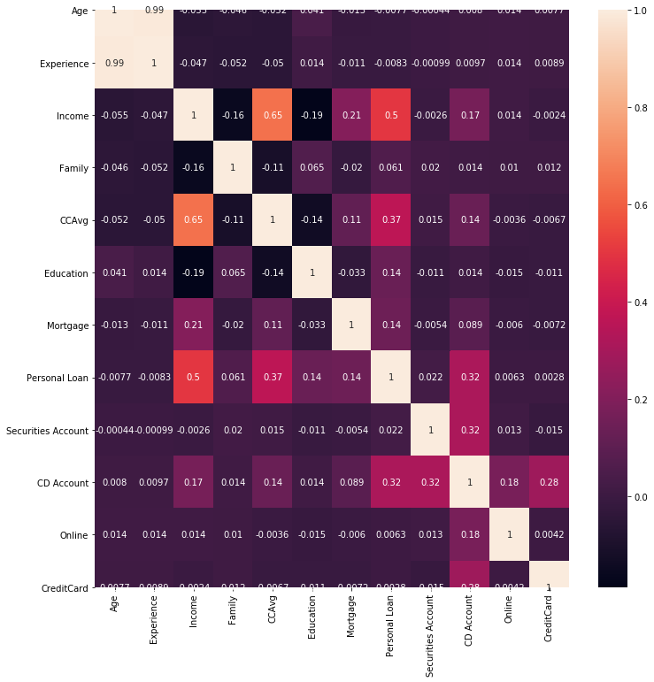

```python
plt.subplots(figsize=(12,12))
sns.heatmap(corrlate,annot=True)
```

1.Here we can see "Age" feature is almost normally distributed where majority of customers are between age 30 to 60 years.Also we can see median is equal to mean.

2."Experience" feature is also almost normally distibuted and mean is also equal to median.But there are some negative values present which should be deleted, as Experience can not be negative.

3.We can see for "Income" , "CCAvg" , "Mortgage" distribution is positively skewed.

5.For "CCAvg" majority of the customers spend less than 2.5K and the average spending is between 0-10K.

6.For "Mortage" we can see that almost 70% of the customers have Value of house mortgage less than 40K and the maximum value is 635K.

7.Distributin of "Family" and "Education" are evenly distributed

8.Income and CCAvg is moderately correlated.

9.Experience and Age gives a positive correlation.

10.Families with income less than 100K are less likely to take loan,than families with high income.

11.The customers whose education level is 1 is having more income than the others.

12.The customers with and without Personal Loan have high Mortage.

13.Families with income less than 100K are less likely to take loan,than families with high income.

14.Ther is no that much impact on Personal Loan if we consider Family attribute. But the Family with size 3 is taking more Personal loan as compare to other family size.¶

# SPLITTING OF DATA INTO TRAINING AND TEST SET WITH 70:30 ratio

```python
X=new_df.drop(["Personal Loan"],axis=1)
y=new_df["Personal Loan"]
```

```python
from sklearn.model_selection import train_test_split
X_train,X_test,y_train,y_test = train_test_split(X,y,test_size=0.30,random_state=1)
```

```python
X_train.shape
```

```
(3500, 11)
```

# Logistic Regression

```python
lr = LogisticRegression() #Instantiate the LogisticRegression object
lr.fit(X_train,y_train) #call the fit method of logistic regression to train the model or to learn the parameters of model
```

```
LogisticRegression(C=1.0, class_weight=None, dual=False, fit_intercept=True,
                   intercept_scaling=1, l1_ratio=None, max_iter=100,
                   multi_class='warn', n_jobs=None, penalty='l2',
                   random_state=None, solver='warn', tol=0.0001, verbose=0,
                   warm_start=False)
```

```python
y_predict = lr.predict(X_test) #predicting the result of test dataset and storing in a variable called y_predict
```

```python
print(accuracy_score(y_test,y_predict))#printing overall accuracy score
```

```
0.9453333333333334
```

```python
print("Confusion matrix")
print(confusion_matrix(y_test,y_predict))#creating confusion matrix
```

```
Confusion matrix
[[1334   17]
 [  65   84]]
```

confusion matrix is a square matrix which will help us to know the class level accuracy so in our test dataset total 1500 entities/customers are there. so (1334+17)=1351, means 1351 customers out of 1500 customers in real not accept personal loan but our model predict 1334/1351 not accept personal loan and for 17 customers it did wrong prediction. likewise, (65+84)=149, means 149 customers out of 1500 customers accept personal loan but our model predict 84/149 accept personal loan and for 65 customers it did wrong prediction.

```python
#displaying precision,recall and f1 score.
df_table = confusion_matrix(y_test,y_predict)
a = (df_table[0,0] + df_table[1,1]) / (df_table[0,0] + df_table[0,1] + df_table[1,0] + df_table[1,1])
p = df_table[1,1] / (df_table[1,1] + df_table[0,1])
r = df_table[1,1] / (df_table[1,1] + df_table[1,0])
f = (2 * p * r) / (p + r)

print("accuracy : ",round(a,2))
print("precision: ",round(p,2))
print("recall   : ",round(r,2))
print("F1 score : ",round(f,2))
```

```
accuracy :  0.95
precision:  0.83
recall   :  0.56
F1 score :  0.67
```

```python
print("precision:",precision_score(y_test,y_predict))
print("recall   :",recall_score(y_test,y_predict))
print("f1 score :",f1_score(y_test,y_predict))
```

```
precision: 0.8316831683168316
recall   : 0.5637583892617449
f1 score : 0.6719999999999999
```

```python
for idx, col_name in enumerate(X_train.columns):
    print("The coeff for {} is {}".format(col_name, lr.coef_[0][idx]))
```

```
The coeff for Age is -0.3861940424001578
The coeff for Experience is 0.38653163131297863
The coeff for Income is 0.048712185563088393
The coeff for Family is 0.6372356963878103
The coeff for CCAvg is 0.16251157823207354
The coeff for Education is 1.6228936500659528
The coeff for Mortgage is 0.0007805656574241508
The coeff for Securities Account is -0.8977387000535308
The coeff for CD Account is 3.271370158719629
The coeff for Online is -0.5881952438102634
The coeff for CreditCard is -1.0178672974567917
```

# K-Nearest Neighbour

```python
knn = KNeighborsClassifier(n_neighbors=5, weights = 'distance') #Initialize the object
knn.fit(X_train,y_train)  #call the fit method of knn classifier to train the model
```

```
KNeighborsClassifier(algorithm='auto', leaf_size=30, metric='minkowski',
                     metric_params=None, n_jobs=None, n_neighbors=5, p=2,
                     weights='distance')
```

```python
knn_y_predict = knn.predict(X_test) #predicting the result of test dataset and storing in a variable called knn_y_predict

knn.score(X_test, y_test)
```

```
0.9093333333333333
```

```python
print(accuracy_score(y_test,knn_y_predict)) #printing overall accuracy score
```

```
0.9093333333333333
```

```
Confusion matrix
[[  55   94]
 [  42 1309]]
```

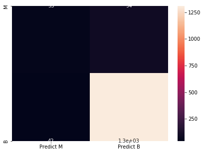

```python
print("Confusion matrix")
cm = confusion_matrix(y_test,knn_y_predict, labels=[1, 0]) #creating confusion matrix
print(cm)
df_cm = pd.DataFrame(cm, index = [i for i in ["M","B"]],columns = [i for i in ["Predict M","Predict B"]])
plt.figure(figsize = (7,5))
sns.heatmap(df_cm, annot=True)
```

```python
#displaying precision,recall and f1 score
print("precision:",precision_score(y_test,knn_y_predict))
print("recall   :",recall_score(y_test,knn_y_predict))
print("f1 score :",f1_score(y_test,knn_y_predict))
```

```
precision: 0.5670103092783505
recall   : 0.3691275167785235
f1 score : 0.44715447154471544
```